# Homework Sheet 3 – Probability, Models & Parameter Estimation

39

Due: Wednesday, December 9 by 11:59 CET

# Instructions

- Create an Rmd-file with your group number (equivalent to StudIP group) in the ‘author’ heading and answer the following questions.
- When all answers are ready, ‘Knit’ the document to produce a HTML file.
- Create a ZIP archive called “IDA_HW03-Group-XYZ.zip” (where ‘XYZ’ is *your* group number) containing:
  - an R Markdown file “IDA_HW03-Group-XYZ.Rmd”
  - a knitted HTML document “IDA_HW03-Group-XYZ.html”
  - any other files necessary to compile your Rmarkdown to HTML (pictures etc.)
- Upload the ZIP archive on Stud.IP in your group folder before the deadline (see above). You may upload as many times as you like before the deadline, only your final submission will count.

# Exercise 1: Sampling from and plotting composite random variables [10 points]

To increase our understanding of how random variables can be thought of as samples, and how composite random variables can easily be constructed by simple operations of samples, we are going to plot a few composite variables. We start with an example.

Let $X$, $Y$ and $Z$ be random variables such that $Z$ is defined in terms of $X$ and $Y$ as follows:

$$\begin{align*}
X & \sim \text{Normal}(0,1) \\
Y & \sim \text{Normal}(5,0.001) \\
Z & \sim X + Y
\end{align*}$$

The goal of this exercise is to build intuitions about the shape of the distribution of $Z$. We do this by imagining sampling. We first sample from $X$ and $Y$, then compute samples of $Z$ in terms of the samples of $X$ and $Y$.

## Ex 1.a Complete the example [3 points]

Complete the code below to obtain a density plot of samples from composite random variable $Z$ as defined in the example above.

```r
n_samples <- 1e6
tibble(
  x = rnorm(n_samples, 0, 1),
  y = rnorm(n_samples, 5 , 0.001),
  z = x+y
  ) %>%
  ggplot(aes(x = z)) +
  geom_density()
```

[output not shown]

## Ex 1.b Increasing standard deviation of $Y$ in previous example [1 point]

Describe in your own words how the shape of $Z$’s distribution will change if we increase the standard deviation of $Y$ to 1. You do not need to plot this, but you may. ## Answer:

## Ex 1.c Irvin-Hall distribution [4 points]

The Irvin-Hall distribution is defined as the sum of $n$ independent draws from a uniform random variable. Formally, if $U_i \sim \text{Uniform}(0,1)$ with $1 \le i \le n$, then $Z \sim \sum_{i=1}^n U_i$ is Irvin-Hall distributed with degree $n$. Use samples to plot the Irvine-Hall distribution for $n=2$, $n=3$ and $n=20$.

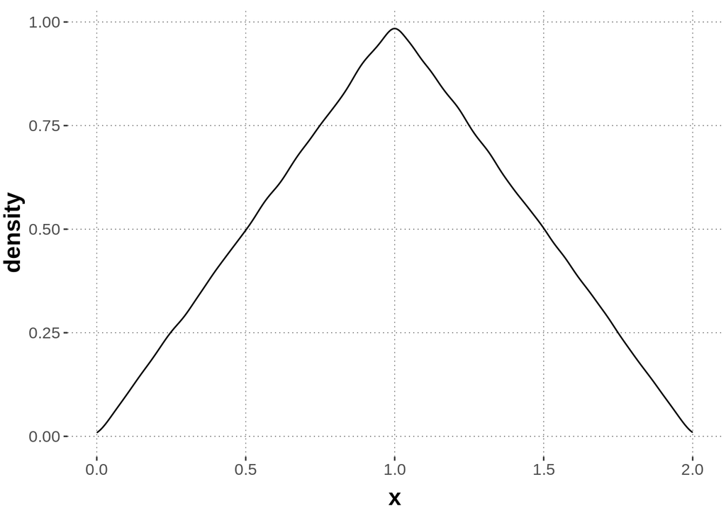

```r
# CHANGED
irvin_hall <- function(degree) {

  n_samples <- 1e6

  cumul <- seq(0, 0, length.out=n_samples)

  for (i in 1:degree) {
    cumul <- cumul + runif(n_samples, 0, 1)
  }


   tibble(x = cumul) %>%
     ggplot(aes(x = x)) +
     geom_density()
   }


irvin_hall(2)
```

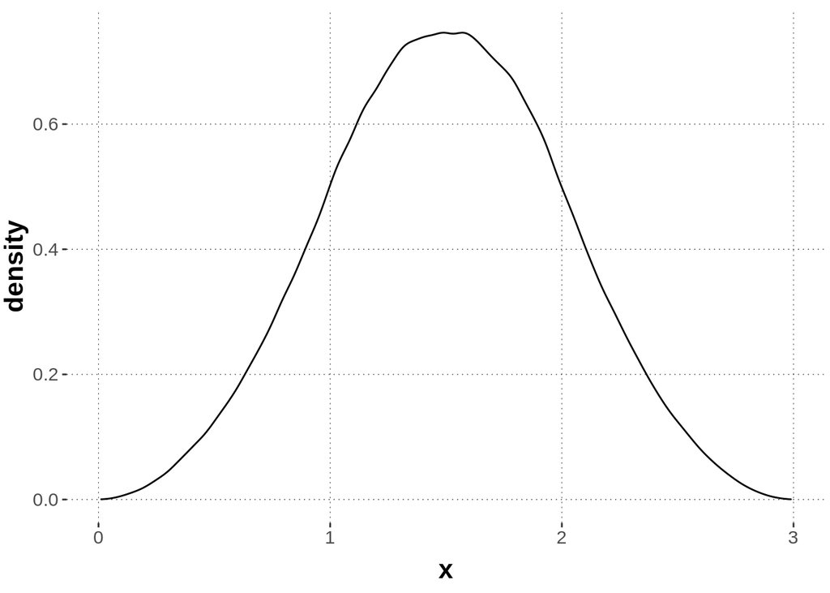

```r
irvin_hall(3)
```

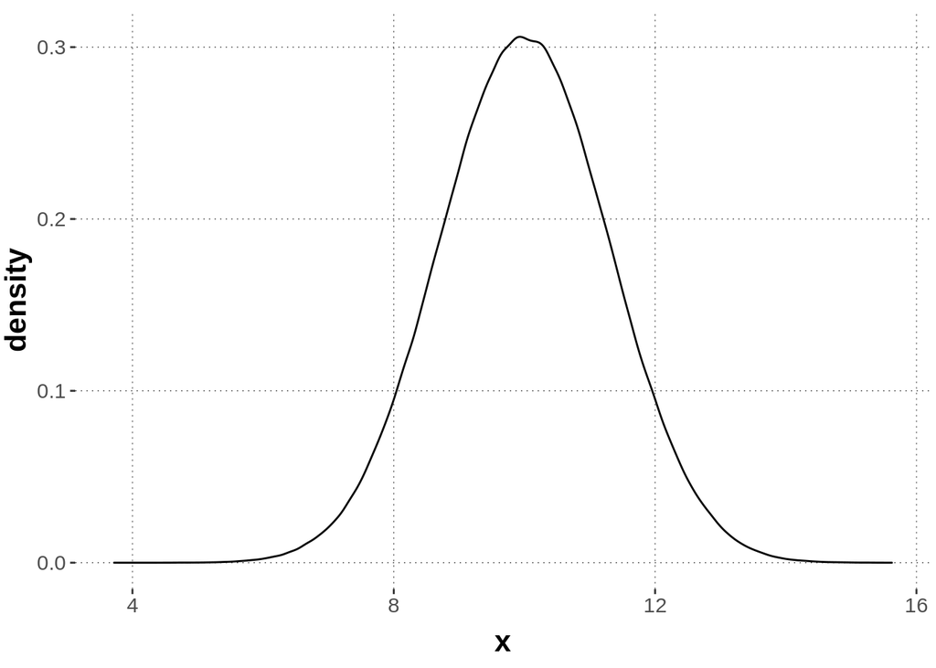

```r
irvin_hall(20)
```